# Reserving in R

# Reserving in R

- ChainLadder
- MRMR

# ChainLadder

Originally developed by Markus Gesmann in late 2007. Now developed by MG with Dan Murphy and Wayne Zhang

Implements many standard reserving techniques:

- Multiplicative chain ladder
- Munich chain ladder
- Bootstrap
- Dave Clark curve fitting

# Basics

```r
library(ChainLadder, verbose=FALSE)
data(RAA)

typeof(RAA)
```

```
## [1] "integer"
```

```r
is.matrix(RAA)
```

```
## [1] TRUE
```

# Have a look at the data

```r
RAA
```

```
##       dev
## origin    1     2     3     4     5     6     7     8     9    10
##   1981 5012  8269 10907 11805 13539 16181 18009 18608 18662 18834
##   1982  106  4285  5396 10666 13782 15599 15496 16169 16704    NA
##   1983 3410  8992 13873 16141 18735 22214 22863 23466    NA    NA
##   1984 5655 11555 15766 21266 23425 26083 27067    NA    NA    NA
##   1985 1092  9565 15836 22169 25955 26180    NA    NA    NA    NA
##   1986 1513  6445 11702 12935 15852    NA    NA    NA    NA    NA
##   1987  557  4020 10946 12314    NA    NA    NA    NA    NA    NA
##   1988 1351  6947 13112    NA    NA    NA    NA    NA    NA    NA
##   1989 3133  5395    NA    NA    NA    NA    NA    NA    NA    NA
##   1990 2063    NA    NA    NA    NA    NA    NA    NA    NA    NA
```

# Plot the data

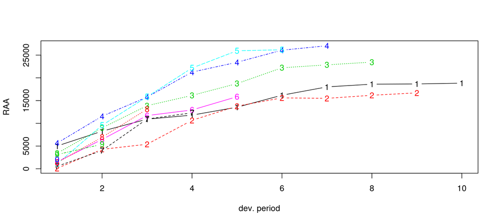

```r
plot(RAA)
```

# Plot option lattice

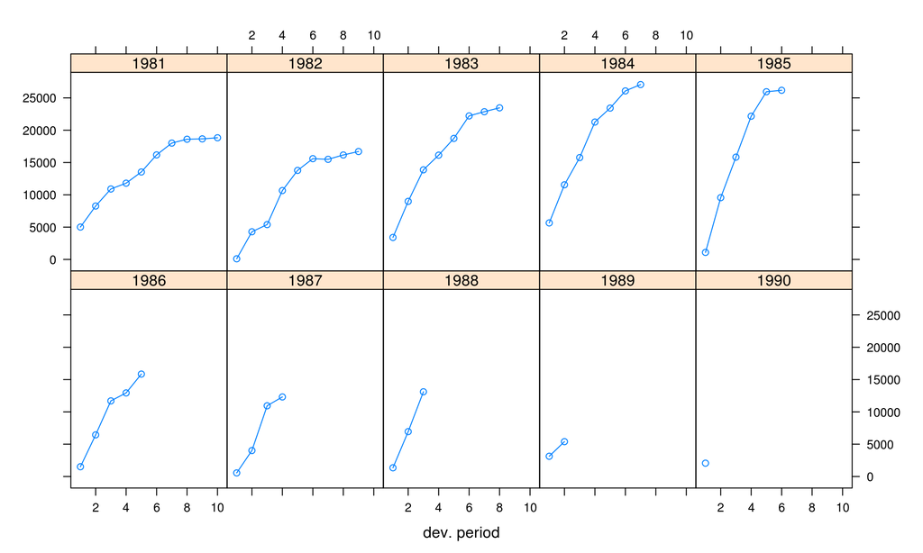

```r
plot(RAA, lattice=TRUE)
```

# Calculation

```r
results = MackChainLadder(Triangle = RAA, est.sigma="Mack")

typeof(results)
```

```
## [1] "list"
```

```r
class(results)
```

```
## [1] "MackChainLadder" "TriangleModel"   "list"
```

# Plot the results

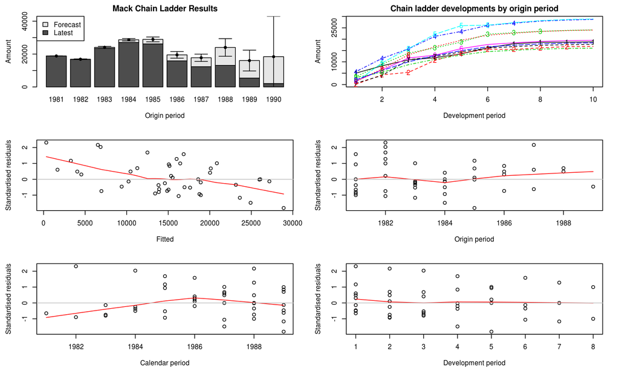

```r
plot(results)
```

# Plot the results as a lattice

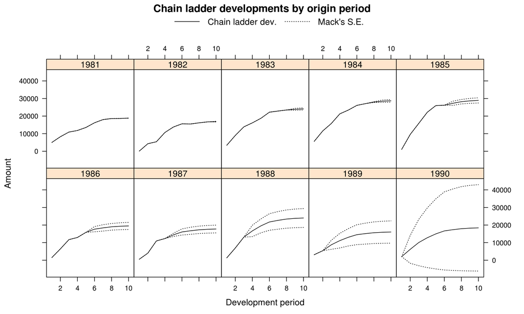

```r
plot(results, lattice=TRUE)
```

# Munich chain ladder

```r
data(MCLpaid)
data(MCLincurred)

is.matrix(MCLpaid)
```

```
## [1] TRUE
```

```r
MunichChainLadder(MCLpaid, MCLincurred,
 est.sigmaP = "log-linear",
 est.sigmaI = "log-linear",
 tailP=FALSE, tailI=FALSE)
```

```
## MunichChainLadder(Paid = MCLpaid, Incurred = MCLincurred, est.sigmaP = "log-linear",
##     est.sigmaI = "log-linear", tailP = FALSE, tailI = FALSE)
##
##   Latest Paid Latest Incurred Latest P/I Ratio Ult. Paid Ult. Incurred
## 1       2,131           2,174            0.980     2,131         2,174
## 2       2,348           2,454            0.957     2,385         2,443
## 3       4,494           4,644            0.968     4,554         4,634
## 4       5,850           6,142            0.952     6,070         6,182
## 5       4,648           4,852            0.958     4,879         4,958
## 6       4,010           4,406            0.910     4,599         4,672
## 7       2,044           5,022            0.407     7,505         7,655
##   Ult. P/I Ratio
## 1          0.980
## 2          0.976
## 3          0.983
## 4          0.982
## 5          0.984
## 6          0.984
## 7          0.980
##
## Totals
##             Paid Incurred P/I Ratio
## Latest:   25,525   29,694      0.86
## Ultimate: 32,121   32,720      0.98
```

# Werner-Modlin data

Data taken from Appendix A of Werner/Modlin. [http://www.casact.org/library/studynotes/werner_modlin_ratemaking.pdf].

```r
library(raw)
data(PPA)
head(PPA_LossDevelopment)
```

```
##   AccidentYear Lag ReportedLossPaidALAE
## 1         2009  15               705088
## 2         2010  15               712475
## 3         2011  15               714196
## 4         2012  15               764101
## 5         2013  15               774384
## 6         2014  15               785068
```

# Convert to ChainLadder triangle

```r
triPPA <- ChainLadder::as.triangle(PPA_LossDevelopment
                                   , origin="AccidentYear"
                                   , dev="Lag"
                                   , value="ReportedLossPaidALAE")
head(triPPA)
```

```
##             Lag
## AccidentYear     15     27     39     51     63
##         2009 705088 725592 738686 753027 732239
##         2010 712475 753295 782248 800258 813949
##         2011 714196 763913 855150 874106 856495
##         2012 764101 861114 884498 867184     NA
##         2013 774384 846167 835120     NA     NA
##         2014 785068 821509     NA     NA     NA
```

# Clark curve

```r
myClarkFit <- ClarkLDF(triPPA, maxage=Inf)
```

# Clark LDF

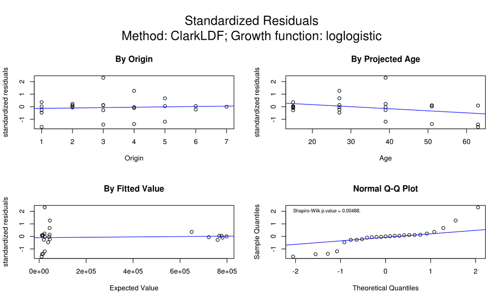

```r
plot(myClarkFit)
```

# What is MRMR?

- Flexible framework for reserving based on linear models
- Linear models = Chain ladder and Additive methods
- Emphasis on:
  - Ease of use
  - Multi-dimensional treatment of data
  - Visualization supports exploratory analysis and assessment of model fit

# Inspirations

- Leigh Halliwell, Jim Guszcza
- Gelman & Hill, “Data Analysis Using Regression and Multilevel/Hierarchical Models”
- ggplot2, lubridate, sp

# Object structure

- OriginPeriod
- St*Measures
- Triangle
- TriangleModel
- TriangleProjection

# Common object properties

- May be thought of as data frames with constraints and metadata
- `[`, `$` accessors
- `rbind`, `c`, `length`
- New generics:
  - `write.excel`
  - `Grow`

# OriginPeriod

```r
library(MRMR)
library(lubridate)
data(NAIC)
op = OriginPeriod(StartDate = as.Date("2001-01-01")
                  , NumPeriods = 10
                  , Period=as.period(1, "years")
                  , Type="Accident Year")
op$Moniker = paste0("AY ", year(op$StartDate))
```

# OriginPeriod (cont’d)

```r
head(as.data.frame(op)[, 1:3])
```

[output not shown]

# Non-standard OriginPeriods

```r
library(lubridate)
startDates = seq(as.Date("2001/01/01")
                 , as.Date("2005/12/31"), by="6 months")
op = OriginPeriod(StartDate=startDates, Period=as.period(6, "months"))
```

| StartDate | EndDate | Moniker | Type | Period |
| --- | --- | --- | --- | --- |
| 2001-01-01 | 2001-06-30 | 2001-01-01 | No type specified | 0 |
| 2001-07-01 | 2001-12-31 | 2001-07-01 | No type specified | 0 |
| 2002-01-01 | 2002-06-30 | 2002-01-01 | No type specified | 0 |
| 2002-07-01 | 2002-12-31 | 2002-07-01 | No type specified | 0 |
| 2003-01-01 | 2003-06-30 | 2003-01-01 | No type specified | 0 |
| 2003-07-01 | 2003-12-31 | 2003-07-01 | No type specified | 0 |

# Member access

```r
op = OriginPeriod(seq(2001:2010))
op$Moniker = paste0("AY ", year(op$StartDate))
x = op[1]
y = op[2:3]
z = c(x, y)
y = op$StartDate
y = op$Type
y = op$Moniker[3]
```

# St*Measures

- St*ticMeasures contain a set of observations associated with an OriginPeriod
- StaticMeasure objects do not vary over time
  - Earned Premium, Payroll, Number of autos
- StochasticMeasure objects vary over time
  - Paid loss, number of open claims

# St*Measures (cont’d)

- Contain a list of Levels of arbitray complexity
  - Each Level has a name and a set of attributes
  - Ex: Line level may have attributes “GL”, “Motor”, etc.
- Contain a set of Measures
  - StochasticMeasure will automatically compute incremental and prior measures

# Examples

All examples use NAIC data compiled by Glen Meyers and Peng Shi of ISO. Available at http://www.casact.org/research/index.cfm?fa=loss_reserves_data

# StaticMeasure construction

```r
op = OriginPeriod(StartDate = as.Date("1988-01-01")
                  , NumPeriods = 10
                  , Period=as.period(1, "year")
                  , Type="Accident Year")
companies <- unique(dfWC$Company)
smWC = StaticMeasure(OriginPeriod = op
                     , Level = list(Company=companies, Line="WC")
                     , Measure=c("DirectEP", "NetEP")
                     , Data=dfWC[dfWC$Lag == 1, ])
```

# StaticMeasure plot

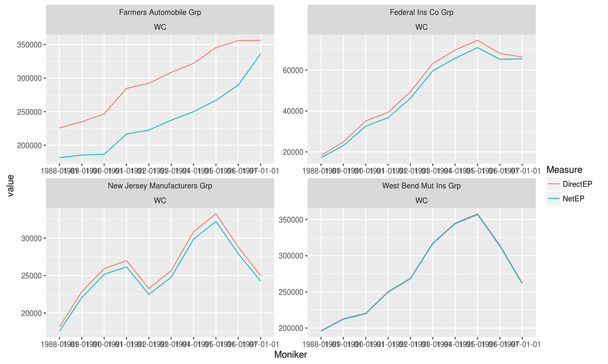

```r
plot(smWC)
```

# StaticMeasure facet plot

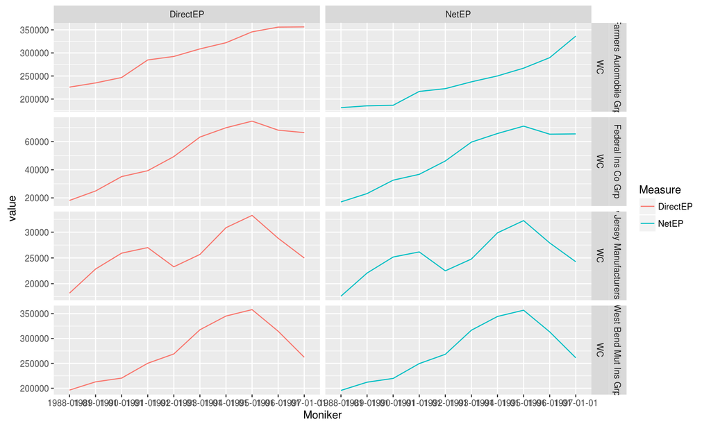

```r
plot(smWC, FacetFormula=as.formula(Line+Company~Measure))
```

# StaticMeasure multidimensional plot

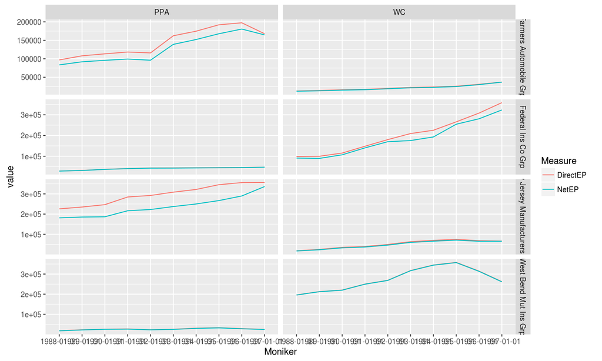

```r
smPPA = StaticMeasure(OriginPeriod = op
                     , Level = list(Company=companies, Line="PPA")
                , Measure=c("DirectEP", "NetEP")
                , Data=dfPPA[dfPPA$Lag == 1, ])
smMulti = c(smPPA, smWC)
plot(smMulti, FacetFormula=as.formula(Company~Line))
```

# StochasticMeasure - Construction

```r
scmWC = StochasticMeasure(OriginPeriod = op
                        , Level=list(Company=companies, Line="WC")
                        , Measure = c("CumulativeIncurred", "CumulativePaid")
                        , DevPeriod = as.period(1, "year")
                        , Lags=1:10
                        , Data=dfWC
                        , OriginPeriodSort = "AccidentYear"
                        , EvaluationDates=seq.Date(as.Date("1988-12-31"), as.Date("2006-12-31"), by="1 year"))
```

# StochasticMeasure - 1

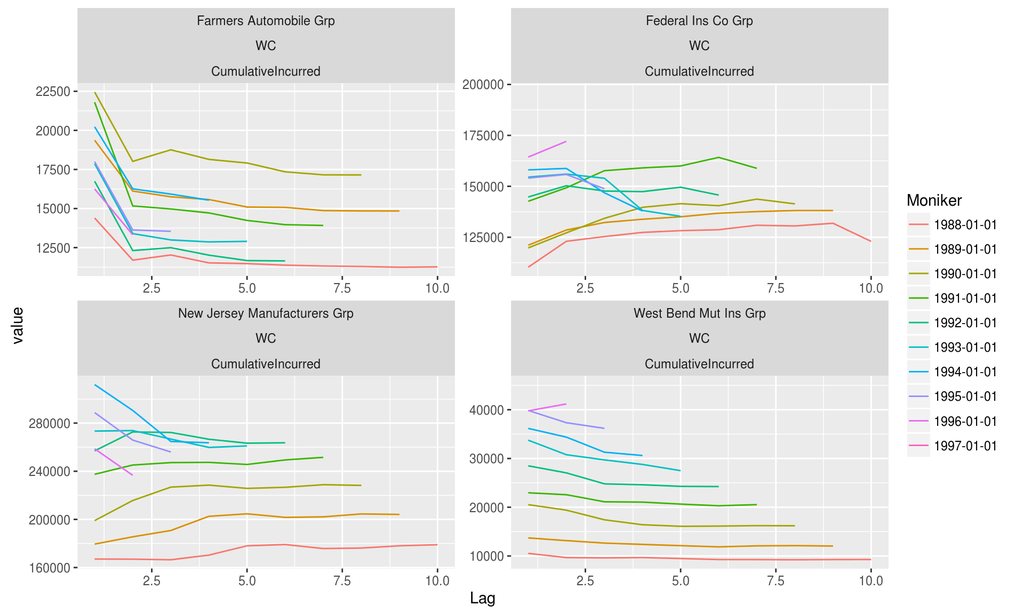

```r
plot(UpperTriangle(scmWC), Measure="CumulativeIncurred")
```

# StochasticMeasure - 2

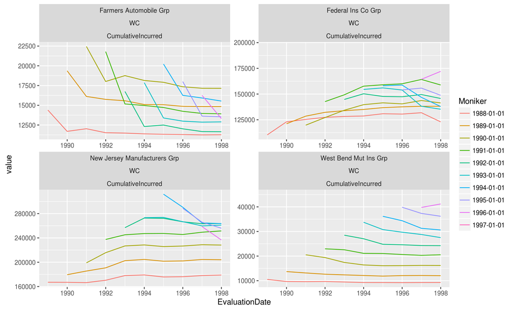

```r
plot(UpperTriangle(scmWC), Measure="CumulativeIncurred", TimeAxis="EvaluationDate")
```

# Triangle

Very simple object. Composed of a StaticMeasure and a StochasticMeasure

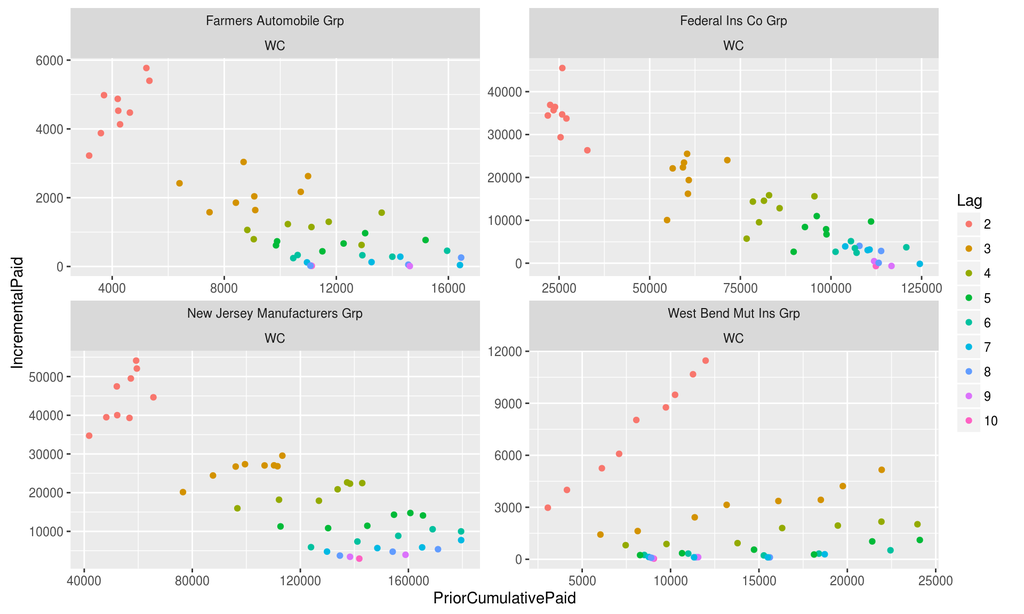

```r
triWC = Triangle(smWC, scmWC, "Workers Comp Triangle")

plot(UpperTriangle(triWC)
     , Response="IncrementalPaid"
     , Predictor="PriorCumulativePaid")
```

# Triangle plot switch variables

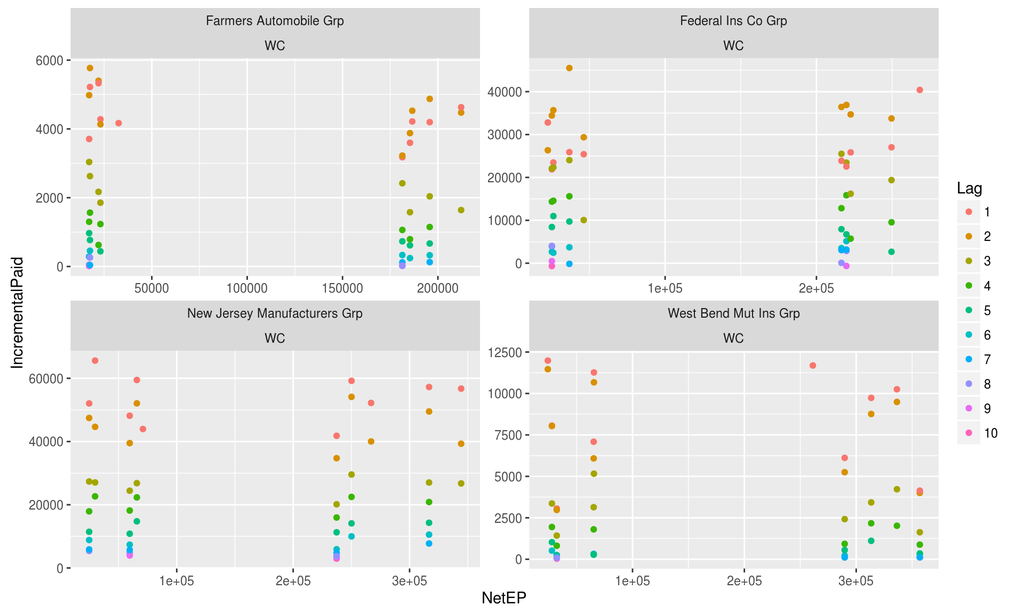

```r
plot(UpperTriangle(triWC)
     , Response="IncrementalPaid"
     , Predictor="NetEP")
```

# TriangleModel

3 Model Types

- individual - Ignore the other data
- pooled - All data is equal
- blended - Weighted average of first two

# TriangleModel

```r
PaidCLPooled =
  TriangleModel(UpperTriangle(triWC)
                , Response = "IncrementalPaid"
                , Predictor = "PriorCumulativePaid"
                , ModelType = "pooled")
```

# Residual plots

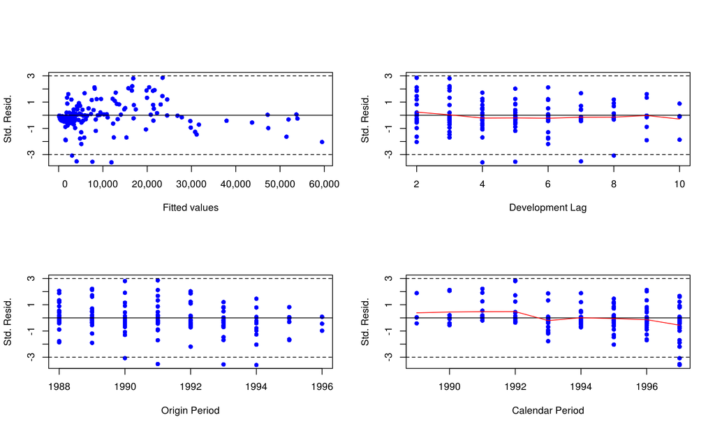

```r
PlotResiduals(PaidCLPooled)
```

# Residual plots 2

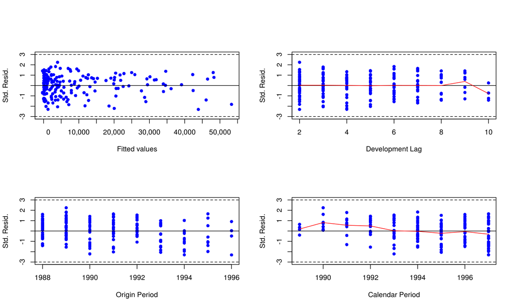

```r
PlotResiduals(PaidCLIndividual)
```

# Residual plots 3

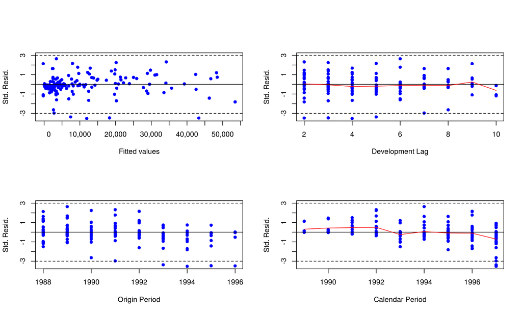

```r
PlotResiduals(PaidCLBlended)
```

# Model comparison

```r
RMSE(PaidCLPooled)
```

```
## [1] 3832.262
```

```r
RMSE(PaidCLIndividual)
```

```
## [1] 2453.553
```

```r
RMSE(PaidCLBlended)
```

```
## [1] 2481.505
```

# Projected results

```r
projPaidCLPooled =
  TriangleProjection(PaidCLPooled
                     , AsOfDate=as.Date("2006-12-31")
                     , MaxLag=10)
```

# Which package?

ChainLadder:

- Excellent for learning/applying basic (and not-so-basic) techniques
- Great to explore which models may fit your data
- Very mature, stable package

MRMR

- Multivariate visualization
- Combine experience of individual groups
- Loss reserving with credibility
- Gateway drug to Bayesian reserving
- Probably harder to use if you’re just starting out with R